# DM03

**演習では，他人のデバイスに触らない。自分のデバイスを，他人に触らせない。**

**新しいノートブックは作らない。**前回（宿題で）作業したノートブックは，Google Driveの「マイドライブ/Colab Notebooks」に保存されているはず。それを開いて再開する。

結果を提示しているのは，計算が正しいことを確認してもらうためである。結果の形式を完全に同じにする必要はない。

## 1 乱数

### 1.1 一様乱数（離散）

**課題** 離散一様乱数を使う例を作れ。

**課題** 離散一様乱数を大量に作ってヒストグラムを描け。ただし，ヒストグラムの全体の面積は $1$ になるようにする。

### 1.2 一様乱数（連続）

**課題** $0$ から $1$ の連続一様乱数を使う例を作れ。

「$0$ から $1$ の連続一様乱数 $X$」の確率密度関数は $f(x):=1$ である。

- $X$ の期待値（平均） $E(X)$ は
  $$E(X):=\int_0^1xf(x)\,dx=\int_0^1x\,dx=\frac{1}{2}.$$
- $X$ の分散 $V(X)$ は
  $$V(X):=E((X-E(X))^2)=\int_0^1(x-\mu)^2f(x)\,dx=\int_0^1\left(x-\frac{1}{2}\right)^2\,dx=\frac{1}{12}.$$

$X_1,\dots,X_{12}$ を$0$ から $1$ の独立な連続一様乱数，$Y:=X_1+\dots+X_{12}$ とすると

- $Y$ の期待値（平均） $E(Y)$ は $12E(X)=6$（$n$ 個の変数の和の期待値は元の期待値の $n$ 倍になるから）。
- $Y$ の分散 $V(Y)$ は $12\times\dfrac{1}{12}=1$（独立な $n$ 個の変数の和の分散は元の分散の $n$ 倍になるから）。

$Z=Y-6$ とすると

- $Z$ の期待値（平均） $E(Z)$ は $6-6=0.$
- $Z$ の分散 $V(Z)$ は $1.$

中心極限定理（同じ種類の乱数をたくさん集めると正規分布に近づく）より，$Z$ が従う確率分布の確率密度関数は $\mathrm{N}(E(Z), V(Z))=\mathrm{N}(0, 1)$（標準正規分布） の確率密度関数と似たものになる。

**課題** $Z$ の実現値を大量に作ってヒストグラムを描け。

$Z$ の実現値のヒストグラム（全体の面積は $1$）と $\mathrm{N}(0, 1)$ の確率密度関数をまとめて描くと次のとおり。

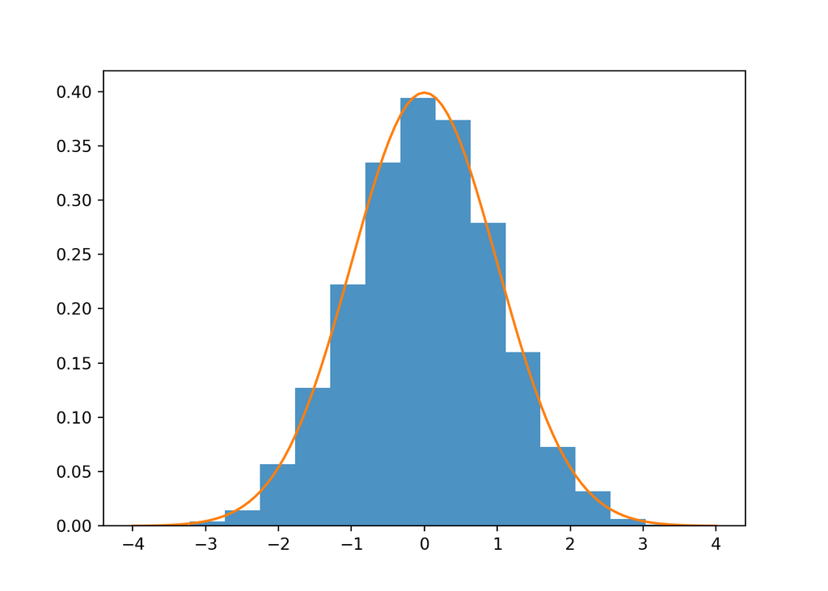

### 1.3 二項乱数

**課題** 「コインを決まった回数投げて表が出た回数を数える」という実験を大量にシミュレートし，結果のヒストグラムを描け。

表が出る確率が $p$ のコインを投げて，出る面を $X$ とする（表なら $X=1$, 裏なら $X=0$）。$X$ の確率関数 $f$ は $f(1):=p, f(0):=1-p$ である。

- $X$ の期待値（平均） $E(X)$ は
  $$E(X):=\sum_{x\in\{0,1\}}xf(x)=0\times
  f(0)+1\times f(1)=0\times(1-p)+1\times p=p.$$
- $X$ の分散 $V(X)$ は
  $$V(X):=\sum_{x\in\{0,1\}}(x-\mu)^2f(x)=(0-\mu)^2f(0)+(1-\mu)^2f(1)=(0-p)^2(1-p)+(1-p)^2p=p(1-p).$$
  このコインを独立に投げた結果を $X_1, \dots, X_n$，$Y:=X_1+\dots+X_n$ とすると
- $Y$ の期待値（平均） $E(Y)$ は $np$（$n$ 個の和の期待値は元の期待値の $n$ 倍になるから）。
- $Y$ の分散 $V(Y)$ は $np(1-p)$（独立な $n$ 個の和の分散は元の分散の$n$ 倍になるから）。

中心極限定理より，$Y$ の確率密度関数は $\mathrm{N}(E(Y), V(Y))=\mathrm{N}(np, np(1-p))$ の確率密度関数と似たものになる。

$Y$ の実現値のヒストグラム（全体の面積は $1$）と $\mathrm{N}(np, np(1-p))$ の確率密度関数をまとめて描くと次のとおり（$n=144$, $p=0.5$ の場合）。

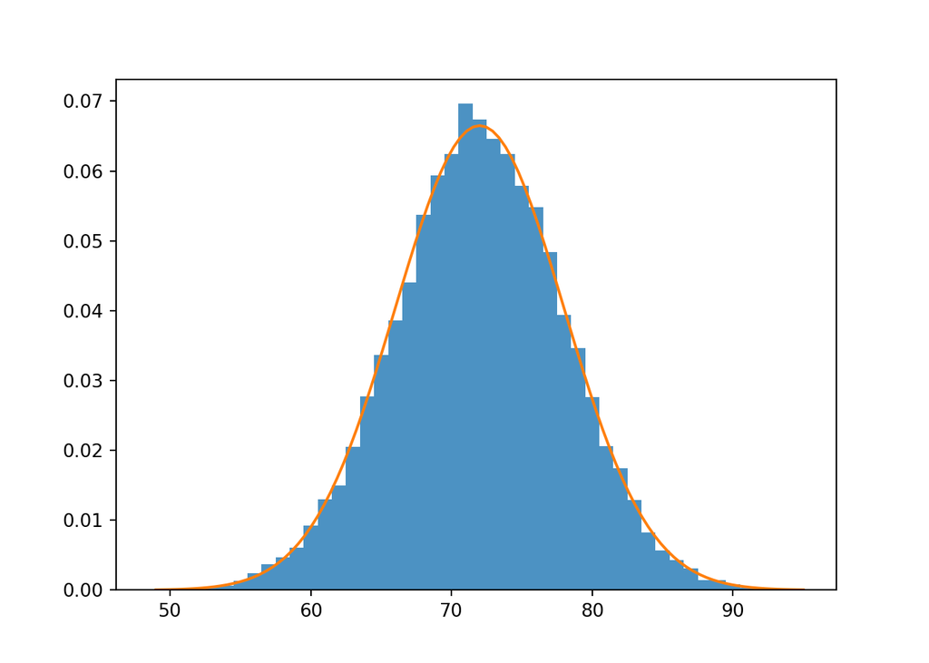

## 2 統計的推測

### 2.1 点推定

話を簡単にするために，母集団の分布を「$0$ から $1$ の連続一様分布」とする。この分布に従う $X$ の期待値（平均）$\mu$ は $\mu:=E(X)=\dfrac{1}{2}$，分散 $\sigma^2$ は $\sigma^2:= V(X)=\dfrac{1}{12}\simeq 0.083$ であることは先に示した。

母集団の母数（$\mu, \sigma^2$）を，知らない振りをして，標本から推定したい。

**課題** 母集団の平均 $\mu$ の推定に向いているのは，標本の平均と中央値のどちらか。シミュレーションで調べよ。

**課題** サンプルサイズを大きくすると $\mu$ の推定がより正確になると思われる。サンプルサイズと推定の正確さの関係を，シミュレーションで調べよ。

**課題** 母集団の分散 $\sigma^2$ の推定に向いているのは，標本の不偏分散と標本分散のどちらか。シミュレーションで調べよ。

### 2.2 仮説検定

コインを $n=100$ 回投げたら表が $x=65$ 回出た。表が出る確率が $p_0=0.5$ なら，表の回数 $X$ の期待値は $np_0=50$ である。実現値 $x=65$ は，期待値からのずれが大きいように見える。表が出る確率 $p$ についての，次の仮説を有意水準 $\alpha=5$ %で検定する（$H_0$ を帰無仮説，$H_1$ を対立仮説という）。
$$H_0: p=p_0,\qquad H_1:p\ne p_0$$

この事例の検定には，三つの方法がある。

1. P値による方法（P値が有意水準未満なら $H_0$ を棄却）
2. 採択域による方法（実現値が採択域外なら $H_0$ を棄却）
3. 信頼区間による方法（$p_0$が信頼区間外なら $H_0$ を棄却）

実現値以上に稀なのは，表が $\{0, 1, \dots, 34, 35, 65, 66, \dots, 99, 100\}$ のいずれかの場合である。このいずれか，つまり実現値以上に稀なことが起こる確率をP値という。

#### 2.2.1 検定方法（その1） P値による方法

- P値が有意水準より小さいとき，稀なことが起きたとみなし，$H_0$ を仮説を棄却する（$H_1$ を採択する）。
- P値が有意水準より大きいとき，稀なことが起きたとみなさず，$H_0$ を棄却しない（$H_0$ を採択する）。

**課題** （検定方法1a 二項分布）${}_nC_k$ は `math.comb(n, k)`で求められる。これを使ってP値を求め，検定の結論を述べよ。ヒント：$\displaystyle\sum_{k\in\{0,\dots,35,65,\dots,100\}}{}_{100}C_k\,p_0^k(1-p_0)^{n-k}=\sum_{k\in\{0,\dots,35,65,\dots,100\}}{}_{100}C_k\,p_0^n$ を求める。

中心極限定理により，表が出る回数は $\mathrm{N}(\mu_0, \sigma_0^2)$ で近似できる。ここで，$\mu_0=np_0=50, \sigma_0^2=np_0(1-p_0)=25$である。

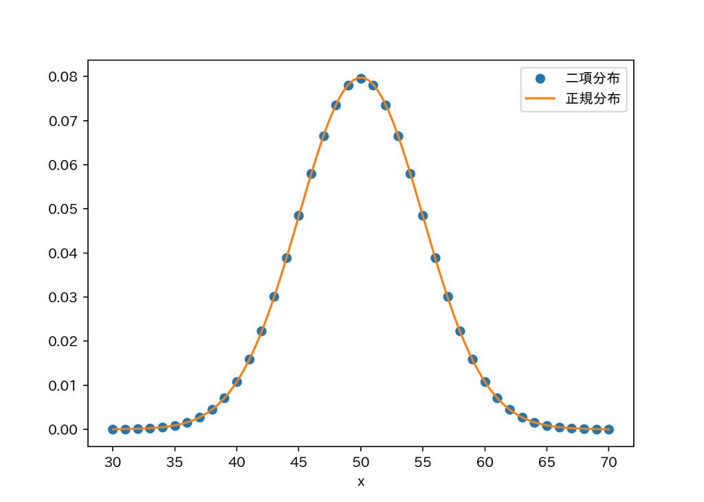

この正規分布 $\mathrm{N}(50, 25)$ を`dist`とする。

```python
n = 100
p0 = 0.5
mu0 = n * p0
sigma0 = np.sqrt(n * p0 * (1 - p0))
dist = stats.norm(mu0, sigma0)
```

正規分布 $\mathrm{N}(50, 25)$ に関する数値の計算方法をまとめる。

| 求めるもの | 方法 |
| --- | --- |
| $P(X=x)$ | `dist.pdf(x)` |
| $P(X\le x)$ | `dist.cdf(x)` |
| $P(x\le X)$ あるいは $1-P(X\le x)$ | `dist.sf(x)` あるいは `1 - dist.cdf(x)` |
| $P(X\le x)=s$ となる $x$ | `dist.ppf(x)` |
| $P(x\le X)=s$ となる $x$ あるいは $P(X\le x)=1-s$ となる $x$ | `dist.isf(x)`あるいは`dist.ppf(1 - s)` |

**課題** （検定方法1b 正規分布近似）$\mathrm{N}(\mu_0, \sigma_0^2)$ に従う $X$ が， $X\le 35\lor 65\le X$ となる確率を求め，検定の結論を述べよ。

```
## 0.0026997960632601866
```

$\mathrm{N}(\mu_0, \sigma_0^2)$ に従う $X$ について，$X<m_0$ となる確率と $M_0<X$ となる確率が，いずれも $\alpha/2$ だとする。このとき，$[m_0, M_0]$を採択域，$(-\infty, m_0)\cup(M_0, \infty)$ を棄却域という。

#### 2.2.2 検定方法（その2） 採択域による方法

**課題** （検定方法2）採択域を求め，検定の結論を述べよ。

```
## 40.20018007729973 59.79981992270027
```

- 実現値 $x=65$ が棄却域に属していれば，$H_0$を棄却する。
- 実現値 $x=65$ が採択域に属していれば，$H_0$を棄却しない（採択する）。

### 2.3 区間推定

少し工夫して信頼区間を求める。標準化スコア $Z:=\dfrac{X-\mu}{\sigma}$ は $\mathrm{N}(0, 1)$ に従う。この確率分布の採択域を $[m, M]$ とすると この確率分布は $Z:=0$ について対称だから，$m=-M$ である。よって，採択域は $[-M, M]$。$\alpha$ を具体的に決めれば，$M$ は数表でも求められる（この結果は覚えてもよい）。

```
## 1.959963984540054
```

#### 2.3.1 検定方法（その3） 信頼区間による方法

実現値 $x$ が採択域に入るとき，$-M\le z:=\dfrac{x-\mu}{\sigma}\le M$ つまり
$$-M\le\frac{x-\mu}{\sigma}=\dfrac{x-np}{\sqrt{np(1-p)}}\le
M$$
である。この不等式を $p$ について解いて，信頼区間を得る。

**課題** $0\le a+4\le 8$ を $a$ について解け。これは不等式を解く練習である。

```python
from sympy import *

var('a');
solve((Le(0, a + 4), Le(a + 4, 8)), a)
```

[output not shown]

**課題** （検定方法3）上の不等式を $p$ について解いて（あるいは[WolframAlphaに解かせて](https://www.wolframalpha.com/input?i=-M%3C%3D%28x-n+p%29%2Fsqrt%28n+p%281-p%29%29%3C%3DM+where+x%3D65%2Cn%3D100%2CM%3D1.96&lang=ja)），$p$ の信頼係数 $1-\alpha$ の信頼区間を求め，検定の結論を述べよ。

```
## (p >= 0.552544432968879) & (p <= 0.736357517569025)
```

信頼区間を求めることと仮説検定を行うことは，表裏一体の関係にある。

- $p=p_0:=0.5$ が信頼区間に属していなければ，$H_0$を棄却する。
- $p=p_0:=0.5$ が信頼区間に属していれば，$H_0$を棄却しない（採択する）。

$p:=U$ のときと $p:=L$ のときの確率密度関数のグラフは次のとおり。$X:=65$は，$p:=L$のときは採択域の最大値，$p:=U$のときは採択域の最小値になる。

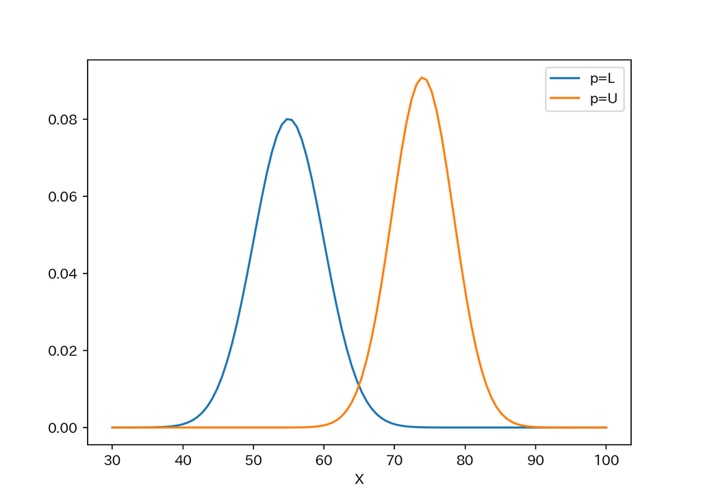

**課題** （時間に余裕がある場合）生成AIで全てをやり直せ．